# Programming Exercise 7: K-means Clustering and Principal Component Analysis

Min Z

November 20, 2017

## Introduction

In this exercise, you will implement the K-means clustering algorithm and apply it to compress an image.

In the second part (ex7_2.rmd), you will use principal component analysis to find a low-dimensional representation of face images.

## 1. K-means Clustering

In this this exercise, you will implement the K-means algorithm and use it for image compression. You will first start on an example 2D dataset that will help you gain an intuition of how the K-means algorithm works. After that, you wil use the K-means algorithm for image compression by reducing the number of colors that occur in an image to only those that are most common in that image.

### 1.1 Implementing K-means

The K-means algorithm is a method to automatically cluster similar data examples together. Concretely, you are given a training set {x(1),…,x(m)} (where x(i) 2 Rn), and want to group the data into a few cohesive “clusters”. The intuition behind K-means is an iterative procedure that starts by guess- ing the initial centroids, and then refines this guess by repeatedly assigning examples to their closest centroids and then recomputing the centroids based on the assignments.

The K-means algorithm is as follows:

```
# % Initialize centroids
centroids = kMeansInitCentroids(X, K);
for iter = 1:iterations
    # % Cluster assignment step: Assign each data point to the
    # % closest centroid. idx(i) corresponds to cˆ(i), the index
    # % of the centroid assigned to example i
    idx = findClosestCentroids(X, centroids);
    # % Move centroid step: Compute means based on centroid
    # % assignments
    centroids = computeMeans(X, idx, K);
end
```

```r
# remove all list
rm(list = ls())
```

Load an example dataset that we will be using

```r
library(R.matlab)
ex7data2 <- readMat("ex7data2.mat")
```

#### 1.1.1 Finding closest centroids

Write function to findClosestCentroids:

%FINDCLOSESTCENTROIDS computes the centroid memberships for every example % idx = FINDCLOSESTCENTROIDS (X, centroids) returns the closest centroids % in idx for a dataset X where each row is a single example. idx = m x 1 % vector of centroid assignments (i.e. each entry in range [1..K])

```r
findClosestCentroids<-function(X, centroids){
  # set K
  K=nrow(centroids)
  # set size: return index of min dist in deach row to idx
  m=nrow(X)
  idx=array(0, dim=c(m,1))
  # initial distance matrix;
  distance = array(0, dim=c(m,K))
  # calculate distance to each centroid
  for (i in 1:K){
    centroidi=centroids[i,]
    # apply margin=1 to rows; sweep margin=2 extend corresponds to STATS
    distance[,i]=apply(sweep(X,MARGIN=2,centroidi,`-`)^2,1,sum)
  }
  mindist=apply(distance,MARGIN = 1,min)
  # return(distance)
  for(i in 1:m){
    # for each record, match index of mindist
    idx[i]=match(mindist[i],distance[i,])
    # console test
    # if(i %in% 1:5){
    #   print(mindist[i])
    #   print(distance[i,])
    #   print(idx[i])}
  }
  return(idx)

}
```

Use initial centroid, compute closest centroid for each record:

```r
# % Select an initial set of centroids
K = 3 # 3 Centroids
initial_centroids = matrix(data=c(3, 3, 6, 2, 8, 5),nrow=3,ncol=2,byrow=T)
# % Find the closest centroids for the examples using the
# % initial_centroids
idx = findClosestCentroids(ex7data2$X, initial_centroids)
```

#### 1.1.2 Computing centroid means

Write function to Compute means:

$$\mu_k:=\frac{1}{|C_k|}\sum\limits_{i=C_k}x^{(i)}$$
`%COMPUTECENTROIDS returs the new centroids by computing the means of the` `%data points assigned to each centroid.` `% centroids = COMPUTECENTROIDS(X, idx, K) returns the new centroids by` `% computing the means of the data points assigned to each centroid. It is` `% given a dataset X where each row is a single data point, a vector` `% idx of centroid assignments (i.e. each entry in range [1..K]) for each` `% example, and K, the number of centroids. You should return a matrix` `% centroids, where each row of centroids is the mean of the data points` `% assigned to it.`

```r
computeCentroids<-function(X, idx, K){
  # dims of X
  m=nrow(X)
  n=ncol(X)
  # dims of centroids to return
  centroids=array(0,dim=c(K,n))
  for(i in 1:K){
    # for each centroid
    # 1) find index of rows in X thats assigned to centroid i:
    idxs = which(idx==i)
    # total # of rows in X assigned to Ci:
    ck=length(idxs)
    # calculate means as the new centroid
    centroids[i,]  = (1/ck)*apply(X[idxs,],2,sum);
  }
  return(centroids)
}
```

Compute means based on the closest centroids found in the previous part.

```r
centroids = computeCentroids(ex7data2$X, idx, K)
```

Centroids computed after initial finding of closest centroids:

| Centroids | data |
| --- | --- |
| Centroid 1 | 2.4283011, 3.1579242 |
| Centroid 2 | 5.8135033, 2.6336565 |
| Centroid 3 | 7.1193869, 3.6166844 |

**Value Check: the centroids should be:**  
[ 2.428301 3.157924 ]  
[ 5.813503 2.633656 ]  
[ 7.119387 3.616684 ]

### 1.2 K-means on example dataset

After you have completed the two functions computeCentroids and findClosestCentroids, you have all the necessary pieces to run the kMeans algorithm. In this part, you will run the K-Means algorithm on the example dataset we have provided.

RUNKMEANS runs the K-Means algorithm on data matrix X, where each row of X is a single example `Runs the K-Means algorithm on data matrix X, where each` `% row of X is a single example. It uses initial_centroids used as the` `% initial centroids. max_iters specifies the total number of interactions` `% of K-Means to execute. plot_progress is a true/false flag that` `% indicates if the function should also plot its progress as the` `% learning happens. This is set to false by default. runkMeans returns` `% centroids, a Kxn matrix of the computed centroids and idx, a m x 1` `% vector of centroid assignments (i.e. each entry in range [1..K])`

```r
runkMeans<-function(X,initial_centroids,max_iters,plot_progress=FALSE){
  # Initialize values
  m=nrow(X)
  n=ncol(X)
  K=nrow(initial_centroids)
  centroids = initial_centroids
  # previous_centroids = centroids
  allcentroids = matrix(data=as.numeric(t(initial_centroids)),nrow=1,byrow = T)
  idx=array(0, dim=c(m,1))

  # Run K-means
  for(i in 1:max_iters){
    # For each example in X, assign it to the closest centroid
    idx = findClosestCentroids(X, centroids);
    # Given the memberships, compute new centroids
    centroids = computeCentroids(X, idx, K);
    # all record to historical centroids
    if(plot_progress){
      allcentroids=rbind(allcentroids,as.numeric(t(centroids)))
    }
  }
  # if(plot_progress){
  #   # if plot_progress == TRUE, do the plot
  #   movepath = as.data.frame(allcentroids)
  # }
  if(plot_progress){
    results<- list("centroids"=centroids,"idx"=idx,"allcentroids"=allcentroids)
  }else{
    results<- list("centroids"=centroids,"idx"=idx)
  }

  return(results)
}
```

Now run on the sample dataset:

```r
# Settings for running K-Means
K = 3
max_iters = 10
initial_centroids = matrix(data=c(3, 3, 6, 2, 8, 5),nrow=3,ncol=2,byrow=T)
# Run K-Means algorithm. The 'true' at the end tells our function to plot the progress of K-Means
returns = runkMeans(ex7data2$X, initial_centroids, max_iters, T)
# centroids<-returns$centroids
idx<-returns$idx
```

> Now that the function runkMeans are run with plot_progress =TRUE, we have all history of centroids flattened stored in returns$allcentroids. So we can plot the result grouping, as well as the moving path of the three group centroids.

Plot data in groups after iterations:

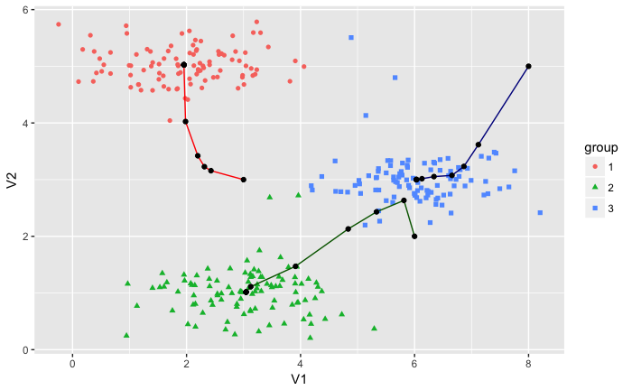

```r
library(ggplot2)
# Set color by cond
data.df<-as.data.frame(ex7data2$X)
group<-as.factor(idx)
p<-ggplot() + geom_point(data=data.df, aes(x=V1, y=V2, color=group, shape=group))
movepath = as.data.frame(returns$allcentroids)
p <- p + geom_path(data=movepath,aes(x=V1, y=V2),colour="red")+
  geom_point(data=movepath,aes(x=V1, y=V2)) +
  geom_path(data=movepath,aes(x=V3, y=V4),colour="darkgreen")+
  geom_point(data=movepath,aes(x=V3, y=V4))+
  geom_path(data=movepath,aes(x=V5, y=V6),colour="darkblue")+
  geom_point(data=movepath,aes(x=V5, y=V6))
p
```

### 1.3 Random initialization

The initial assignments of centroids for the example dataset in this exercise were designed so that you will see the same figure as in Figure above. In practice, a good strategy for initializing the centroids is to select random examples from the training set.

`% Initialize the centroids to be random examples` `% Randomly reorder the indices of examples` `randidx = randperm(size(X, 1));` `% Take the first K examples as centroids` `centroids = X(randidx(1:K), :);`

`%KMEANSINITCENTROIDS This function initializes K centroids that are to be` `%used in K-Means on the dataset X` `% centroids = KMEANSINITCENTROIDS(X, K) returns K initial centroids to be` `% used with the K-Means on the dataset X`

```r
kMeansInitCentroids<-function(X, K){

  n=ncol(X)
  centroids = array(0, dim=c(K,n))
  # Randomly reorder the indices of examples
  # shuffle row-wise
  reX = X[sample(nrow(X)),]
  # Take the first K examples as centroids
  centroids = reX[1:K,]
  # centroids = X[sample(K),]
  return(centroids)
}
```

Use random inital centroids:

```r
# Settings for running K-Means
X = ex7data2$X
K = 3
max_iters = 10
initial_centroids_rand = kMeansInitCentroids(X, K)
# Run K-Means algorithm. The 'true' at the end tells our function to plot the progress of K-Means
returns_rand = runkMeans(X, initial_centroids_rand, max_iters, T)
centroids_rand<-returns_rand$centroids
idx_rand<-returns_rand$idx
```

Plot data in groups after iterations:

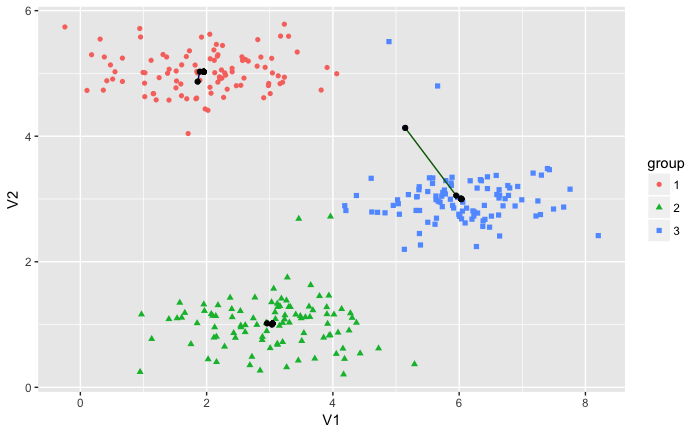

```r
# Set color by cond
data.df<-as.data.frame(ex7data2$X)
group<-as.factor(idx)
p<-ggplot() + geom_point(data=data.df, aes(x=V1, y=V2, color=group, shape=group))
movepath = as.data.frame(returns_rand$allcentroids)
p <- p + geom_path(data=movepath,aes(x=V1, y=V2),colour="red")+
  geom_point(data=movepath,aes(x=V1, y=V2)) +
  geom_path(data=movepath,aes(x=V3, y=V4),colour="darkgreen")+
  geom_point(data=movepath,aes(x=V3, y=V4))+
  geom_path(data=movepath,aes(x=V5, y=V6),colour="darkblue")+
  geom_point(data=movepath,aes(x=V5, y=V6))
p
```

### 1.3* Use kmeans function from stats package

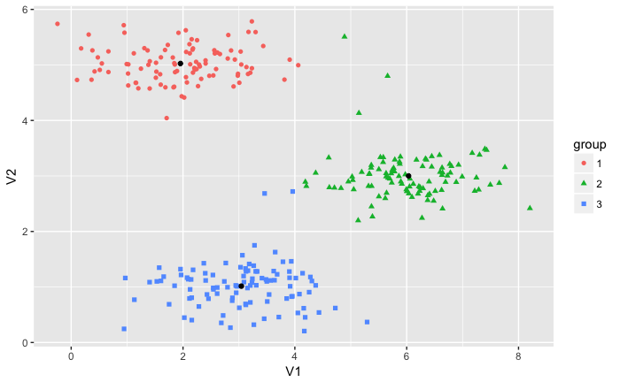

```r
kmeans.rs<-kmeans(ex7data2$X,3,iter.max = 10,nstart = 3,algorithm = "Lloyd")
# plot results
group<-as.factor(kmeans.rs$cluster)
p<-ggplot() + geom_point(data=data.df, aes(x=V1, y=V2, color=group, shape=group))
centerstoplot = as.data.frame(kmeans.rs$centers)
p <- p +
  geom_point(data=centerstoplot,aes(x=V1, y=V2))
p
```

### 1.4 Image compression with K-means

#### 1.4.1 K-Means Clustering on Pixels

In this exercise, you will use K-Means to compress an image. To do this, you will first run K-Means on the colors of the pixels in the image and then you will map each pixel on to it’s closest centroid.

load data

```r
# load library png to read in png as array
library(png)
imgbirdread = readPNG("bird_small.png")
# check with mat version of data. or if cannot read png
# bird_small  <- readMat("bird_small.mat")
# imgbird = bird_small$A
```

`This creates a three-dimensional matrix A whose first two indices identify a pixel position and whose last index represents red, green, or blue. For example, A(50, 33, 3) gives the blue intensity of the pixel at row 50 and column 33.`

pre process data:

```r
# A = imgbird/ 255
# % Divide by 255 so that all values are in the range 0 - 1
A = imgbirdread
# read png using readPNG, transformed to 0-1 already
dimA = dim(A)
# % Reshape the image into an Nx3 matrix where N = number of pixels.
# % Each row will contain the Red, Green and Blue pixel values
# % This gives us our dataset matrix X that we will use K-Means on.
X = array(A,dim=c(dimA[1]*dimA[2],dimA[3]))
```

Run your K-Means algorithm on this data You should try different values of K and max_iters here Also, when using K-Means, it is important the initialize the centroids randomly.

```r
K = 16
max_iters = 10
initial_centroidsimg = kMeansInitCentroids(X, K)
```

Run K-Means

```r
returns = runkMeans(X, initial_centroidsimg, max_iters, FALSE)
centroidsimg<-returns$centroids
idximg<-returns$idx
```

```r
# recover scale of colors on  16 centroids found
 C<-centroidsimg
```

#### 1.4.2 Image Compression

After finding the top K = 16 colors to represent the image, you can now assign each pixel position to its closest centroid using the findClosestCentroids function. This allows you to represent the original image using the centroid assignments of each pixel.

```r
 # Find closest cluster members
idx = findClosestCentroids(X, centroidsimg)
```

Essentially, now we have represented the image X as in terms of the indices in idx.

We can now recover the image from the indices (idx) by mapping each pixel (specified by it’s index in idx) to the centroid value. Reshape the recovered image into proper dimensions

```r
X_recovered = centroidsimg[idx,]
X_recovered = array(X_recovered, dim=c(dimA[1],dimA[2],dimA[3]))
```

Now, show comparison of orignal image:

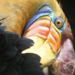

A local image

Compressed image:

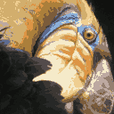

A local image